# Slicing and dicing

Jae Yeon Kim

07 March, 2022

# 1 Manipulating (dplyr)

## 1.1 Setup

```r
pacman::p_load(tidyverse, gapminder)
```

## 1.2 Big ideas

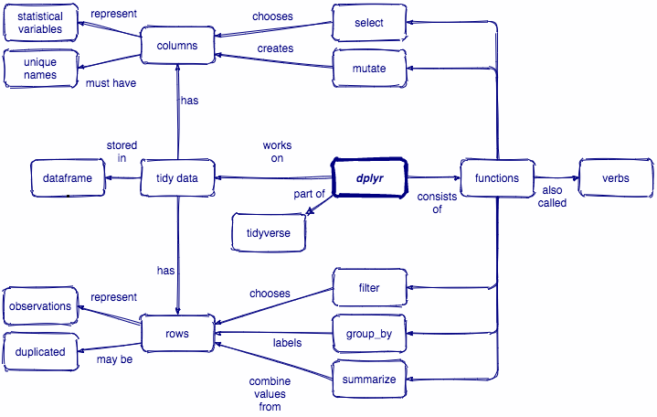

Concept map for dplyr. By Monica Alonso, Greg Wilson.

`dplyr` is better than the base R approaches to data processing:

- fast to run (due to the C++ backed) and intuitive to type
- works well with tidy data and databases (thanks to [`dbplyr`](https://dbplyr.tidyverse.org/))

## 1.3 Rearranging

- Arrange
- Order rows

```r
dplyr::arrange(mtcars, mpg) # Low to High (default)
```

|  | mpg | cyl | disp | hp | drat | wt | qsec | vs | am | gear | carb |
| --- | --- | --- | --- | --- | --- | --- | --- | --- | --- | --- | --- |
| Cadillac Fleetwood | 10.4 | 8 | 472.0 | 205 | 2.93 | 5.250 | 17.98 | 0 | 0 | 3 | 4 |
| Lincoln Continental | 10.4 | 8 | 460.0 | 215 | 3.00 | 5.424 | 17.82 | 0 | 0 | 3 | 4 |
| Camaro Z28 | 13.3 | 8 | 350.0 | 245 | 3.73 | 3.840 | 15.41 | 0 | 0 | 3 | 4 |
| Duster 360 | 14.3 | 8 | 360.0 | 245 | 3.21 | 3.570 | 15.84 | 0 | 0 | 3 | 4 |
| Chrysler Imperial | 14.7 | 8 | 440.0 | 230 | 3.23 | 5.345 | 17.42 | 0 | 0 | 3 | 4 |
| Maserati Bora | 15.0 | 8 | 301.0 | 335 | 3.54 | 3.570 | 14.60 | 0 | 1 | 5 | 8 |
| Merc 450SLC | 15.2 | 8 | 275.8 | 180 | 3.07 | 3.780 | 18.00 | 0 | 0 | 3 | 3 |
| AMC Javelin | 15.2 | 8 | 304.0 | 150 | 3.15 | 3.435 | 17.30 | 0 | 0 | 3 | 2 |
| Dodge Challenger | 15.5 | 8 | 318.0 | 150 | 2.76 | 3.520 | 16.87 | 0 | 0 | 3 | 2 |
| Ford Pantera L | 15.8 | 8 | 351.0 | 264 | 4.22 | 3.170 | 14.50 | 0 | 1 | 5 | 4 |

[output cut: 22 more lines]

```r
dplyr::arrange(mtcars, desc(mpg)) # High to Row
```

|  | mpg | cyl | disp | hp | drat | wt | qsec | vs | am | gear | carb |
| --- | --- | --- | --- | --- | --- | --- | --- | --- | --- | --- | --- |
| Toyota Corolla | 33.9 | 4 | 71.1 | 65 | 4.22 | 1.835 | 19.90 | 1 | 1 | 4 | 1 |
| Fiat 128 | 32.4 | 4 | 78.7 | 66 | 4.08 | 2.200 | 19.47 | 1 | 1 | 4 | 1 |
| Honda Civic | 30.4 | 4 | 75.7 | 52 | 4.93 | 1.615 | 18.52 | 1 | 1 | 4 | 2 |
| Lotus Europa | 30.4 | 4 | 95.1 | 113 | 3.77 | 1.513 | 16.90 | 1 | 1 | 5 | 2 |
| Fiat X1-9 | 27.3 | 4 | 79.0 | 66 | 4.08 | 1.935 | 18.90 | 1 | 1 | 4 | 1 |
| Porsche 914-2 | 26.0 | 4 | 120.3 | 91 | 4.43 | 2.140 | 16.70 | 0 | 1 | 5 | 2 |
| Merc 240D | 24.4 | 4 | 146.7 | 62 | 3.69 | 3.190 | 20.00 | 1 | 0 | 4 | 2 |
| Datsun 710 | 22.8 | 4 | 108.0 | 93 | 3.85 | 2.320 | 18.61 | 1 | 1 | 4 | 1 |
| Merc 230 | 22.8 | 4 | 140.8 | 95 | 3.92 | 3.150 | 22.90 | 1 | 0 | 4 | 2 |
| Toyota Corona | 21.5 | 4 | 120.1 | 97 | 3.70 | 2.465 | 20.01 | 1 | 0 | 3 | 1 |

[output cut: 22 more lines]

- Rename
- Rename columns

```r
df <- tibble(y = c(2011, 2012, 2013))

df %>%
  rename(
    Year = # NEW name
      y
  ) # OLD name
```

| Year |
| --- |
| 2011 |
| 2012 |
| 2013 |

### 1.3.1 Subset observations (rows)

- Choose row by logical condition
- Single condition

```r
starwars %>%
  dplyr::filter(gender == "feminine") %>%
  arrange(desc(height))
```

| name | height | mass | hair_color | skin_color | eye_color | birth_year | sex | gender | homeworld | species | films | vehicles | starships |
| --- | --- | --- | --- | --- | --- | --- | --- | --- | --- | --- | --- | --- | --- |
| Taun We | 213 | NA | none | grey | black | NA | female | feminine | Kamino | Kaminoan |  |  |  |
| Adi Gallia | 184 | 50.0 | none | dark | blue | NA | female | feminine | Coruscant | Tholothian |  |  |  |
| Ayla Secura | 178 | 55.0 | none | blue | hazel | 48 | female | feminine | Ryloth | Twi'lek |  |  |  |
| Shaak Ti | 178 | 57.0 | none | red, blue, white | black | NA | female | feminine | Shili | Togruta |  |  |  |
| Luminara Unduli | 170 | 56.2 | black | yellow | blue | 58 | female | feminine | Mirial | Mirialan |  |  |  |
| Zam Wesell | 168 | 55.0 | blonde | fair, green, yellow | yellow | NA | female | feminine | Zolan | Clawdite |  |  |  |
| Jocasta Nu | 167 | NA | white | fair | blue | NA | female | feminine | Coruscant | Human |  |  |  |
| Barriss Offee | 166 | 50.0 | black | yellow | blue | 40 | female | feminine | Mirial | Mirialan |  |  |  |
| Beru Whitesun lars | 165 | 75.0 | brown | light | blue | 47 | female | feminine | Tatooine | Human |  |  |  |
| Dormé | 165 | NA | brown | light | brown | NA | female | feminine | Naboo | Human |  |  |  |

[output cut: 7 more lines]

The following filtering example was inspired by [the suzanbert’s dplyr blog post](https://suzan.rbind.io/2018/02/dplyr-tutorial-3/).

- Multiple conditions (numeric)

```r
# First example
starwars %>%
  dplyr::filter(height < 180, height > 160) %>%
  nrow()
```

```
## [1] 24
```

```r
# Same as above
starwars %>%
  dplyr::filter(height < 180 & height > 160) %>%
  nrow()
```

```
## [1] 24
```

```r
# Not same as above
starwars %>%
  dplyr::filter(height < 180 | height > 160) %>%
  nrow()
```

```
## [1] 81
```

**Challenge**

1. Use `filter(between())` to find characters whose heights are between 180 and 160 and (2) count the number of these observations.
- Minimum reproducible example

```r
df <- tibble(
  heights = c(160:180),
  char = rep("none", length(c(160:180)))
)
```

- Multiple conditions (character)

```r
# Filter names include ars; `grepl` is a base R function

starwars %>%
  dplyr::filter(grepl("ars", tolower(name)))
```

| name | height | mass | hair_color | skin_color | eye_color | birth_year | sex | gender | homeworld | species | films | vehicles | starships |
| --- | --- | --- | --- | --- | --- | --- | --- | --- | --- | --- | --- | --- | --- |
| Owen Lars | 178 | 120 | brown, grey | light | blue | 52 | male | masculine | Tatooine | Human |  |  |  |
| Beru Whitesun lars | 165 | 75 | brown | light | blue | 47 | female | feminine | Tatooine | Human |  |  |  |
| Quarsh Panaka | 183 | NA | black | dark | brown | 62 | NA | NA | Naboo | NA |  |  |  |
| Cliegg Lars | 183 | NA | brown | fair | blue | 82 | male | masculine | Tatooine | Human |  |  |  |

```r
# Or, if you prefer dplyr way

starwars %>%
  dplyr::filter(str_detect(tolower(name), "ars"))
```

| name | height | mass | hair_color | skin_color | eye_color | birth_year | sex | gender | homeworld | species | films | vehicles | starships |
| --- | --- | --- | --- | --- | --- | --- | --- | --- | --- | --- | --- | --- | --- |
| Owen Lars | 178 | 120 | brown, grey | light | blue | 52 | male | masculine | Tatooine | Human |  |  |  |
| Beru Whitesun lars | 165 | 75 | brown | light | blue | 47 | female | feminine | Tatooine | Human |  |  |  |
| Quarsh Panaka | 183 | NA | black | dark | brown | 62 | NA | NA | Naboo | NA |  |  |  |
| Cliegg Lars | 183 | NA | brown | fair | blue | 82 | male | masculine | Tatooine | Human |  |  |  |

```r
# Filter brown and black hair_color

starwars %>%
  dplyr::filter(hair_color %in% c("black", "brown"))
```

| name | height | mass | hair_color | skin_color | eye_color | birth_year | sex | gender | homeworld | species | films | vehicles | starships |
| --- | --- | --- | --- | --- | --- | --- | --- | --- | --- | --- | --- | --- | --- |
| Leia Organa | 150 | 49.0 | brown | light | brown | 19.0 | female | feminine | Alderaan | Human |  |  |  |
| Beru Whitesun lars | 165 | 75.0 | brown | light | blue | 47.0 | female | feminine | Tatooine | Human |  |  |  |
| Biggs Darklighter | 183 | 84.0 | black | light | brown | 24.0 | male | masculine | Tatooine | Human |  |  |  |
| Chewbacca | 228 | 112.0 | brown | unknown | blue | 200.0 | male | masculine | Kashyyyk | Wookiee |  |  |  |
| Han Solo | 180 | 80.0 | brown | fair | brown | 29.0 | male | masculine | Corellia | Human |  |  |  |
| Wedge Antilles | 170 | 77.0 | brown | fair | hazel | 21.0 | male | masculine | Corellia | Human |  |  |  |
| Jek Tono Porkins | 180 | 110.0 | brown | fair | blue | NA | male | masculine | Bestine IV | Human |  |  |  |
| Boba Fett | 183 | 78.2 | black | fair | brown | 31.5 | male | masculine | Kamino | Human |  |  |  |
| Lando Calrissian | 177 | 79.0 | black | dark | brown | 31.0 | male | masculine | Socorro | Human |  |  |  |
| Arvel Crynyd | NA | NA | brown | fair | brown | NA | male | masculine | NA | Human |  |  |  |

[output cut: 21 more lines]

**Challenge**

Use `str_detect()` to find characters whose names include “Han”.

```r
# Your turn
```

- Choose row by position (row index)

```r
starwars %>%
  arrange(desc(height)) %>%
  slice(1:6)
```

| name | height | mass | hair_color | skin_color | eye_color | birth_year | sex | gender | homeworld | species | films | vehicles | starships |
| --- | --- | --- | --- | --- | --- | --- | --- | --- | --- | --- | --- | --- | --- |
| Yarael Poof | 264 | NA | none | white | yellow | NA | male | masculine | Quermia | Quermian |  |  |  |
| Tarfful | 234 | 136 | brown | brown | blue | NA | male | masculine | Kashyyyk | Wookiee |  |  |  |
| Lama Su | 229 | 88 | none | grey | black | NA | male | masculine | Kamino | Kaminoan |  |  |  |
| Chewbacca | 228 | 112 | brown | unknown | blue | 200 | male | masculine | Kashyyyk | Wookiee |  |  |  |
| Roos Tarpals | 224 | 82 | none | grey | orange | NA | male | masculine | Naboo | Gungan |  |  |  |
| Grievous | 216 | 159 | none | brown, white | green, yellow | NA | male | masculine | Kalee | Kaleesh |  |  |  |

- Sample by a fraction

```r
# For reproducibility
set.seed(1234)

# Old way

starwars %>%
  sample_frac(0.10,
    replace = FALSE
  ) # Without replacement
```

| name | height | mass | hair_color | skin_color | eye_color | birth_year | sex | gender | homeworld | species | films | vehicles | starships |
| --- | --- | --- | --- | --- | --- | --- | --- | --- | --- | --- | --- | --- | --- |
| Arvel Crynyd | NA | NA | brown | fair | brown | NA | male | masculine | NA | Human |  |  |  |
| Sly Moore | 178 | 48 | none | pale | white | NA | NA | NA | Umbara | NA |  |  |  |
| IG-88 | 200 | 140 | none | metal | red | 15.0 | none | masculine | NA | Droid |  |  |  |
| Biggs Darklighter | 183 | 84 | black | light | brown | 24.0 | male | masculine | Tatooine | Human |  |  |  |
| Leia Organa | 150 | 49 | brown | light | brown | 19.0 | female | feminine | Alderaan | Human |  |  |  |
| Watto | 137 | NA | black | blue, grey | yellow | NA | male | masculine | Toydaria | Toydarian |  |  |  |
| Jabba Desilijic Tiure | 175 | 1358 | NA | green-tan, brown | orange | 600.0 | hermaphroditic | masculine | Nal Hutta | Hutt |  |  |  |
| Darth Vader | 202 | 136 | none | white | yellow | 41.9 | male | masculine | Tatooine | Human |  |  |  |
| Taun We | 213 | NA | none | grey | black | NA | female | feminine | Kamino | Kaminoan |  |  |  |

```r
# New way

starwars %>%
  slice_sample(
    prop = 0.10,
    replace = FALSE
  )
```

| name | height | mass | hair_color | skin_color | eye_color | birth_year | sex | gender | homeworld | species | films | vehicles | starships |
| --- | --- | --- | --- | --- | --- | --- | --- | --- | --- | --- | --- | --- | --- |
| Raymus Antilles | 188 | 79.0 | brown | light | brown | NA | male | masculine | Alderaan | Human |  |  |  |
| Tarfful | 234 | 136.0 | brown | brown | blue | NA | male | masculine | Kashyyyk | Wookiee |  |  |  |
| Han Solo | 180 | 80.0 | brown | fair | brown | 29.0 | male | masculine | Corellia | Human |  |  |  |
| Mas Amedda | 196 | NA | none | blue | blue | NA | male | masculine | Champala | Chagrian |  |  |  |
| Barriss Offee | 166 | 50.0 | black | yellow | blue | 40.0 | female | feminine | Mirial | Mirialan |  |  |  |
| Darth Vader | 202 | 136.0 | none | white | yellow | 41.9 | male | masculine | Tatooine | Human |  |  |  |
| Finn | NA | NA | black | dark | dark | NA | male | masculine | NA | Human |  |  |  |
| Boba Fett | 183 | 78.2 | black | fair | brown | 31.5 | male | masculine | Kamino | Human |  |  |  |

- Sample by number

```r
# Old way

starwars %>%
  sample_n(20,
    replace = FALSE
  ) # Without replacement
```

| name | height | mass | hair_color | skin_color | eye_color | birth_year | sex | gender | homeworld | species | films | vehicles | starships |
| --- | --- | --- | --- | --- | --- | --- | --- | --- | --- | --- | --- | --- | --- |
| Quarsh Panaka | 183 | NA | black | dark | brown | 62 | NA | NA | Naboo | NA |  |  |  |
| Poe Dameron | NA | NA | brown | light | brown | NA | male | masculine | NA | Human |  |  |  |
| Mas Amedda | 196 | NA | none | blue | blue | NA | male | masculine | Champala | Chagrian |  |  |  |
| Zam Wesell | 168 | 55 | blonde | fair, green, yellow | yellow | NA | female | feminine | Zolan | Clawdite |  |  |  |
| Leia Organa | 150 | 49 | brown | light | brown | 19 | female | feminine | Alderaan | Human |  |  |  |
| Jango Fett | 183 | 79 | black | tan | brown | 66 | male | masculine | Concord Dawn | Human |  |  |  |
| Ben Quadinaros | 163 | 65 | none | grey, green, yellow | orange | NA | male | masculine | Tund | Toong |  |  |  |
| Padmé Amidala | 165 | 45 | brown | light | brown | 46 | female | feminine | Naboo | Human |  |  |  |
| Mace Windu | 188 | 84 | none | dark | brown | 72 | male | masculine | Haruun Kal | Human |  |  |  |
| R2-D2 | 96 | 32 | NA | white, blue | red | 33 | none | masculine | Naboo | Droid |  |  |  |

[output cut: 10 more lines]

```r
# New way

starwars %>%
  slice_sample(
    n = 20,
    replace = FALSE
  ) # Without replacement
```

| name | height | mass | hair_color | skin_color | eye_color | birth_year | sex | gender | homeworld | species | films | vehicles | starships |
| --- | --- | --- | --- | --- | --- | --- | --- | --- | --- | --- | --- | --- | --- |
| Owen Lars | 178 | 120 | brown, grey | light | blue | 52 | male | masculine | Tatooine | Human |  |  |  |
| Ki-Adi-Mundi | 198 | 82 | white | pale | yellow | 92 | male | masculine | Cerea | Cerean |  |  |  |
| Captain Phasma | NA | NA | unknown | unknown | unknown | NA | NA | NA | NA | NA |  |  |  |
| Gregar Typho | 185 | 85 | black | dark | brown | NA | male | masculine | Naboo | Human |  |  |  |
| R5-D4 | 97 | 32 | NA | white, red | red | NA | none | masculine | Tatooine | Droid |  |  |  |
| Ackbar | 180 | 83 | none | brown mottle | orange | 41 | male | masculine | Mon Cala | Mon Calamari |  |  |  |
| Wedge Antilles | 170 | 77 | brown | fair | hazel | 21 | male | masculine | Corellia | Human |  |  |  |
| Dormé | 165 | NA | brown | light | brown | NA | female | feminine | Naboo | Human |  |  |  |
| Rey | NA | NA | brown | light | hazel | NA | female | feminine | NA | Human |  |  |  |
| IG-88 | 200 | 140 | none | metal | red | 15 | none | masculine | NA | Droid |  |  |  |

[output cut: 10 more lines]

- Top 10 rows orderd by height

```r
# Old way
starwars %>%
  top_n(10, height)
```

| name | height | mass | hair_color | skin_color | eye_color | birth_year | sex | gender | homeworld | species | films | vehicles | starships |
| --- | --- | --- | --- | --- | --- | --- | --- | --- | --- | --- | --- | --- | --- |
| Darth Vader | 202 | 136 | none | white | yellow | 41.9 | male | masculine | Tatooine | Human |  |  |  |
| Chewbacca | 228 | 112 | brown | unknown | blue | 200.0 | male | masculine | Kashyyyk | Wookiee |  |  |  |
| Roos Tarpals | 224 | 82 | none | grey | orange | NA | male | masculine | Naboo | Gungan |  |  |  |
| Rugor Nass | 206 | NA | none | green | orange | NA | male | masculine | Naboo | Gungan |  |  |  |
| Yarael Poof | 264 | NA | none | white | yellow | NA | male | masculine | Quermia | Quermian |  |  |  |
| Lama Su | 229 | 88 | none | grey | black | NA | male | masculine | Kamino | Kaminoan |  |  |  |
| Taun We | 213 | NA | none | grey | black | NA | female | feminine | Kamino | Kaminoan |  |  |  |
| Grievous | 216 | 159 | none | brown, white | green, yellow | NA | male | masculine | Kalee | Kaleesh |  |  |  |
| Tarfful | 234 | 136 | brown | brown | blue | NA | male | masculine | Kashyyyk | Wookiee |  |  |  |
| Tion Medon | 206 | 80 | none | grey | black | NA | male | masculine | Utapau | Pau'an |  |  |  |

```r
# New way
starwars %>%
  slice_max(height, n = 10) # Variable first, Argument second
```

| name | height | mass | hair_color | skin_color | eye_color | birth_year | sex | gender | homeworld | species | films | vehicles | starships |
| --- | --- | --- | --- | --- | --- | --- | --- | --- | --- | --- | --- | --- | --- |
| Yarael Poof | 264 | NA | none | white | yellow | NA | male | masculine | Quermia | Quermian |  |  |  |
| Tarfful | 234 | 136 | brown | brown | blue | NA | male | masculine | Kashyyyk | Wookiee |  |  |  |
| Lama Su | 229 | 88 | none | grey | black | NA | male | masculine | Kamino | Kaminoan |  |  |  |
| Chewbacca | 228 | 112 | brown | unknown | blue | 200.0 | male | masculine | Kashyyyk | Wookiee |  |  |  |
| Roos Tarpals | 224 | 82 | none | grey | orange | NA | male | masculine | Naboo | Gungan |  |  |  |
| Grievous | 216 | 159 | none | brown, white | green, yellow | NA | male | masculine | Kalee | Kaleesh |  |  |  |
| Taun We | 213 | NA | none | grey | black | NA | female | feminine | Kamino | Kaminoan |  |  |  |
| Rugor Nass | 206 | NA | none | green | orange | NA | male | masculine | Naboo | Gungan |  |  |  |
| Tion Medon | 206 | 80 | none | grey | black | NA | male | masculine | Utapau | Pau'an |  |  |  |
| Darth Vader | 202 | 136 | none | white | yellow | 41.9 | male | masculine | Tatooine | Human |  |  |  |

### 1.3.2 Subset variables (columns)

```r
names(msleep)
```

```
##  [1] "name"         "genus"        "vore"         "order"        "conservation"
##  [6] "sleep_total"  "sleep_rem"    "sleep_cycle"  "awake"        "brainwt"
## [11] "bodywt"
```

- Select only numeric columns

```r
# Only numeric
msleep %>%
  dplyr::select(where(is.numeric))
```

| sleep_total | sleep_rem | sleep_cycle | awake | brainwt | bodywt |
| --- | --- | --- | --- | --- | --- |
| 12.1 | NA | NA | 11.90 | NA | 50.000 |
| 17.0 | 1.8 | NA | 7.00 | 0.01550 | 0.480 |
| 14.4 | 2.4 | NA | 9.60 | NA | 1.350 |
| 14.9 | 2.3 | 0.1333333 | 9.10 | 0.00029 | 0.019 |
| 4.0 | 0.7 | 0.6666667 | 20.00 | 0.42300 | 600.000 |
| 14.4 | 2.2 | 0.7666667 | 9.60 | NA | 3.850 |
| 8.7 | 1.4 | 0.3833333 | 15.30 | NA | 20.490 |
| 7.0 | NA | NA | 17.00 | NA | 0.045 |
| 10.1 | 2.9 | 0.3333333 | 13.90 | 0.07000 | 14.000 |
| 3.0 | NA | NA | 21.00 | 0.09820 | 14.800 |

[output cut: 73 more lines]

**Challenge**

Use `select(where())` to find only non-numeric columns

```r
# Your turn
```

- Select the columns that include “sleep” in their names

```r
msleep %>%
  dplyr::select(contains("sleep"))
```

| sleep_total | sleep_rem | sleep_cycle |
| --- | --- | --- |
| 12.1 | NA | NA |
| 17.0 | 1.8 | NA |
| 14.4 | 2.4 | NA |
| 14.9 | 2.3 | 0.1333333 |
| 4.0 | 0.7 | 0.6666667 |
| 14.4 | 2.2 | 0.7666667 |
| 8.7 | 1.4 | 0.3833333 |
| 7.0 | NA | NA |
| 10.1 | 2.9 | 0.3333333 |
| 3.0 | NA | NA |

[output cut: 73 more lines]

- Select the columns that include either “sleep” or “wt” in their names
- Basic R way

`grepl` is one of the R base pattern matching functions.

```r
msleep[grepl("sleep|wt", names(msleep))]
```

| sleep_total | sleep_rem | sleep_cycle | brainwt | bodywt |
| --- | --- | --- | --- | --- |
| 12.1 | NA | NA | NA | 50.000 |
| 17.0 | 1.8 | NA | 0.01550 | 0.480 |
| 14.4 | 2.4 | NA | NA | 1.350 |
| 14.9 | 2.3 | 0.1333333 | 0.00029 | 0.019 |
| 4.0 | 0.7 | 0.6666667 | 0.42300 | 600.000 |
| 14.4 | 2.2 | 0.7666667 | NA | 3.850 |
| 8.7 | 1.4 | 0.3833333 | NA | 20.490 |
| 7.0 | NA | NA | NA | 0.045 |
| 10.1 | 2.9 | 0.3333333 | 0.07000 | 14.000 |
| 3.0 | NA | NA | 0.09820 | 14.800 |

[output cut: 73 more lines]

**Challenge**

Use `select(match())` to find columns whose names include either “sleep” or “wt”.

- Select the columns that start with “b”

```r
msleep %>%
  dplyr::select(starts_with("b"))
```

| brainwt | bodywt |
| --- | --- |
| NA | 50.000 |
| 0.01550 | 0.480 |
| NA | 1.350 |
| 0.00029 | 0.019 |
| 0.42300 | 600.000 |
| NA | 3.850 |
| NA | 20.490 |
| NA | 0.045 |
| 0.07000 | 14.000 |
| 0.09820 | 14.800 |

[output cut: 73 more lines]

- Select the columns that end with “wt”

```r
msleep %>%
  dplyr::select(ends_with("wt"))
```

| brainwt | bodywt |
| --- | --- |
| NA | 50.000 |
| 0.01550 | 0.480 |
| NA | 1.350 |
| 0.00029 | 0.019 |
| 0.42300 | 600.000 |
| NA | 3.850 |
| NA | 20.490 |
| NA | 0.045 |
| 0.07000 | 14.000 |
| 0.09820 | 14.800 |

[output cut: 73 more lines]

- Select the columns using both beginning and end string patterns

The key idea is you can use Boolean operators (`!`, `&`, `|`)to combine different string pattern matching statements.

```r
msleep %>%
  dplyr::select(starts_with("b") & ends_with("wt"))
```

| brainwt | bodywt |
| --- | --- |
| NA | 50.000 |
| 0.01550 | 0.480 |
| NA | 1.350 |
| 0.00029 | 0.019 |
| 0.42300 | 600.000 |
| NA | 3.850 |
| NA | 20.490 |
| NA | 0.045 |
| 0.07000 | 14.000 |
| 0.09820 | 14.800 |

[output cut: 73 more lines]

- Select the order and move it before everything

```r
# By specifying a column
msleep %>%
  dplyr::select(order, everything())
```

| order | name | genus | vore | conservation | sleep_total | sleep_rem | sleep_cycle | awake | brainwt | bodywt |
| --- | --- | --- | --- | --- | --- | --- | --- | --- | --- | --- |
| Carnivora | Cheetah | Acinonyx | carni | lc | 12.1 | NA | NA | 11.90 | NA | 50.000 |
| Primates | Owl monkey | Aotus | omni | NA | 17.0 | 1.8 | NA | 7.00 | 0.01550 | 0.480 |
| Rodentia | Mountain beaver | Aplodontia | herbi | nt | 14.4 | 2.4 | NA | 9.60 | NA | 1.350 |
| Soricomorpha | Greater short-tailed shrew | Blarina | omni | lc | 14.9 | 2.3 | 0.1333333 | 9.10 | 0.00029 | 0.019 |
| Artiodactyla | Cow | Bos | herbi | domesticated | 4.0 | 0.7 | 0.6666667 | 20.00 | 0.42300 | 600.000 |
| Pilosa | Three-toed sloth | Bradypus | herbi | NA | 14.4 | 2.2 | 0.7666667 | 9.60 | NA | 3.850 |
| Carnivora | Northern fur seal | Callorhinus | carni | vu | 8.7 | 1.4 | 0.3833333 | 15.30 | NA | 20.490 |
| Rodentia | Vesper mouse | Calomys | NA | NA | 7.0 | NA | NA | 17.00 | NA | 0.045 |
| Carnivora | Dog | Canis | carni | domesticated | 10.1 | 2.9 | 0.3333333 | 13.90 | 0.07000 | 14.000 |
| Artiodactyla | Roe deer | Capreolus | herbi | lc | 3.0 | NA | NA | 21.00 | 0.09820 | 14.800 |

[output cut: 73 more lines]

- Select variables from a character vector.

```r
msleep %>%
  dplyr::select(any_of(c("name", "order"))) %>%
  colnames()
```

```
## [1] "name"  "order"
```

- Select the variables named in character + number pattern

```r
msleep$week8 <- NA

msleep$week12 <- NA

msleep$week_extra <- 0

msleep %>%
  dplyr::select(num_range("week", c(1:12)))
```

| week8 | week12 |
| --- | --- |
| NA | NA |
| NA | NA |
| NA | NA |
| NA | NA |
| NA | NA |
| NA | NA |
| NA | NA |
| NA | NA |
| NA | NA |
| NA | NA |

[output cut: 73 more lines]

**Additional tips**

`msleep` data has nicely cleaned column names. But real-world data are usually messier. The `janitor` package is useful to fix this kind of problem.

```r
messy_df <- tibble::tribble(
  ~"ColNum1", ~"COLNUM2", ~"COL & NUM3",
  1, 2, 3
)

messy_df
```

| ColNum1 | COLNUM2 | COL & NUM3 |
| --- | --- | --- |
| 1 | 2 | 3 |

```r
pacman::p_load(janitor)

janitor::clean_names(messy_df)
```

| col_num1 | colnum2 | col_num3 |
| --- | --- | --- |
| 1 | 2 | 3 |

`janitor::tabyl()` is helpful for doing crosstabulation and a nice alternative to `table()` function.

```r
# Frequency table; The default output class is table
table(gapminder$country)
```

```
##
##              Afghanistan                  Albania                  Algeria
##                       12                       12                       12
##                   Angola                Argentina                Australia
##                       12                       12                       12
##                  Austria                  Bahrain               Bangladesh
##                       12                       12                       12
##                  Belgium                    Benin                  Bolivia
##                       12                       12                       12
##   Bosnia and Herzegovina                 Botswana                   Brazil
##                       12                       12                       12
##                 Bulgaria             Burkina Faso                  Burundi
##                       12                       12                       12
##                 Cambodia                 Cameroon                   Canada
##                       12                       12                       12
## Central African Republic                     Chad                    Chile
##                       12                       12                       12
##                    China                 Colombia                  Comoros
##                       12                       12                       12
##         Congo, Dem. Rep.              Congo, Rep.               Costa Rica
##                       12                       12                       12
##            Cote d'Ivoire                  Croatia                     Cuba
##                       12                       12                       12
##           Czech Republic                  Denmark                 Djibouti
##                       12                       12                       12
##       Dominican Republic                  Ecuador                    Egypt
##                       12                       12                       12
##              El Salvador        Equatorial Guinea                  Eritrea
##                       12                       12                       12
##                 Ethiopia                  Finland                   France
##                       12                       12                       12
##                    Gabon                   Gambia                  Germany
##                       12                       12                       12
##                    Ghana                   Greece                Guatemala
##                       12                       12                       12
##                   Guinea            Guinea-Bissau                    Haiti
##                       12                       12                       12
##                 Honduras         Hong Kong, China                  Hungary
##                       12                       12                       12
##                  Iceland                    India                Indonesia
```

[output cut: 42 more lines]

```
##                       12                       12                       12
##              Switzerland                    Syria                   Taiwan
##                       12                       12                       12
##                 Tanzania                 Thailand                     Togo
##                       12                       12                       12
##      Trinidad and Tobago                  Tunisia                   Turkey
##                       12                       12                       12
##                   Uganda           United Kingdom            United States
##                       12                       12                       12
##                  Uruguay                Venezuela                  Vietnam
##                       12                       12                       12
##       West Bank and Gaza              Yemen, Rep.                   Zambia
##                       12                       12                       12
##                 Zimbabwe
##                       12
```

```r
# Frequency table (unique value, n, percentage)
janitor::tabyl(gapminder$country)
```

| gapminder$country | n | percent |
| --- | --- | --- |
| Afghanistan | 12 | 0.007042254 |
| Albania | 12 | 0.007042254 |
| Algeria | 12 | 0.007042254 |
| Angola | 12 | 0.007042254 |
| Argentina | 12 | 0.007042254 |
| Australia | 12 | 0.007042254 |
| Austria | 12 | 0.007042254 |
| Bahrain | 12 | 0.007042254 |
| Bangladesh | 12 | 0.007042254 |
| Belgium | 12 | 0.007042254 |

[output cut: 132 more lines]

```r
# If you want to add percentage ...
gapminder %>%
  tabyl(country) %>%
  adorn_pct_formatting(digits = 0, affix_sign = TRUE)
```

| country | n | percent |
| --- | --- | --- |
| Afghanistan | 12 | 1% |
| Albania | 12 | 1% |
| Algeria | 12 | 1% |
| Angola | 12 | 1% |
| Argentina | 12 | 1% |
| Australia | 12 | 1% |
| Austria | 12 | 1% |
| Bahrain | 12 | 1% |
| Bangladesh | 12 | 1% |
| Belgium | 12 | 1% |

[output cut: 132 more lines]

# 2 Creating variables

## 2.1 Change values using conditions

You can think of `case_when()` (multiple conditions) as an extended version of `ifelse()` (binary conditions).

```r
mtcars <- mtcars %>%
  mutate(cyl_dummy = case_when(
    cyl > median(cyl) ~ "High", # if condition
    cyl < median(cyl) ~ "Low", # else if condition
    TRUE ~ "Median"
  )) # else condition

mtcars %>% pull(cyl_dummy)
```

```
##  [1] "Median" "Median" "Low"    "Median" "High"   "Median" "High"   "Low"
##  [9] "Low"    "Median" "Median" "High"   "High"   "High"   "High"   "High"
## [17] "High"   "Low"    "Low"    "Low"    "Low"    "High"   "High"   "High"
## [25] "High"   "Low"    "Low"    "Low"    "High"   "Median" "High"   "Low"
```

## 2.2 Change values manually

```r
mtcars %>%
  mutate(cyl_dummy = recode(cyl_dummy, # Target column
    "High" = "2", # Old - New
    "Low" = "0",
    "Median" = "1"
  )) %>%
  pull(cyl_dummy)
```

```
##  [1] "1" "1" "0" "1" "2" "1" "2" "0" "0" "1" "1" "2" "2" "2" "2" "2" "2" "0" "0"
## [20] "0" "0" "2" "2" "2" "2" "0" "0" "0" "2" "1" "2" "0"
```